# Reproducible Research: Peer Assessment 1

## Loading and Processing the Data

Loading the data from a zip file into R and the processing into a more managable format.

```r
## Loading and preprocessing the data
unzip("~/Desktop/Coursera/repdata-data-activity.zip")
activity <- read.csv("activity.csv")
```

## What is the mean total number of steps taken per day?

Make a histogram of the total number of steps taken each day.

```r
stepsPerDay <- tapply(activity$steps, activity$date, sum, na.rm = T)
```

Histogram of the total number of steps taken per day.

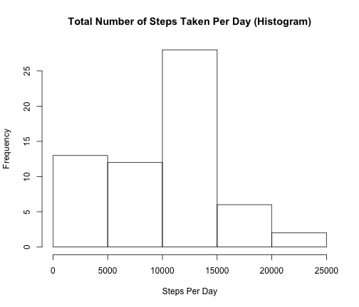

```r
## Histogram
    hist(stepsPerDay, main = "Total Number of Steps Taken Per Day (Histogram)",
      xlab = "Steps Per Day")
```

Then, calculate and report the mean and median total number of steps taken per day.

```r
    ## Mean & Median
    print(mean_stepsDaily <- mean(stepsPerDay))
```

```
## [1] 9354
```

```r
    print(med_stepsDaily <- median(stepsPerDay))
```

```
## [1] 10395
```

## What is the average daily activity pattern?

Make a time series plot of the 5-minute intervals(x-axis) and the average number of stpes taken, averaged across all days(y-axis).

```r
dailyInterval <- tapply(activity$steps, as.factor(activity$interval), mean,
                           na.rm = T)
```

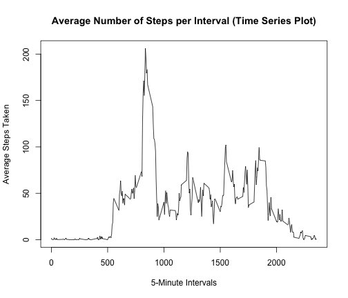

```r
## Time series Plot
    plot(levels(as.factor(activity$interval)), dailyInterval, type = "l", xlab = "5-Minute Intervals",
     ylab = "Average Steps Taken", main = "Average Number of Steps per Interval (Time Series Plot)")
```

Then, find which 5-minute interval on average aacross the days in the dataset has the maxium number of steps.

```r
    ## Max Number of Steps
    names(dailyInterval)[which(dailyInterval == max(dailyInterval))]
```

```
## [1] "835"
```

## Inputing missing values

Note that there are a number of days/intervals where there are missing values( coded as NA). The presence of missing days may intriduce bias into some calculates or summaries of the data.

Calculate and report the total number of missing values in the dataset( the total number of rows with NAs).

```r
## Calculate total numbers of missing values
    sum(is.na(activity$steps))
```

```
## [1] 2304
```

Replace the NA's and create a new dataset that is equal to the original dataset but with the missing data filled in.

```r
    replaceMissing <- function() {

    activityMissing <- activity

    for (i in 1:length(activityMissing$steps)) {
        if (is.na(activityMissing$steps[i])) {
            interval <- as.character(activityMissing$interval[i])
            intervalmean <- dailyInterval[interval]
            activityMissing$steps[i] <- intervalmean
        } else {
            ##return
        }

    }

    activityMissing <<- activityMissing
}

source("replaceMissing.R")
replaceMissing()
```

New Total Steps without Missing Data.

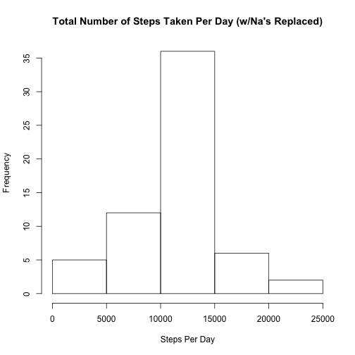

```r
    stepsPerDayTotal <- tapply(activityMissing$steps, activityMissing$date,
                               sum, na.rm = T)

    ## Create Histogram of the total number of steps taken each day.
    ## Histogram of Newly caluculated Data & Previous Historgram with NAs
    hist(stepsPerDayTotal, main = "Total Number of Steps Taken Per Day (w/Na's Replaced)",
     xlab = "Steps Per Day")
```

[figure not shown]

```r
    hist(stepsPerDayTotal, main = "Total Number of Steps Taken Per Day (w/ NA's)",
     xlab = "Steps per day")
```

Calculate and report the mean/median os total number of steps taken per day. You will see that these values differ from the above diagram.

```r
    ## New Mean
    print(stepsPerDayTotalMean <- mean(stepsPerDayTotal),
                sep = " ")
```

```
## [1] 10766
```

```r
    ## New Median
    print(stepsPerDayTotalMed <- median(stepsPerDayTotal),
                sep = " ")
```

```
## [1] 10766
```

For this part the weekdays() function may be of some help here. Use the dataset with the filled-in missing values for the part.

```r
stepsPerDayTotal$date <- as.character(stepsPerDayTotal$date)
```

[output not shown]

```r
stepsPerDayTotal$date <- as.Date(stepsPerDayTotal$date)
```

[output not shown]

```r
weekdays <- (weekdays(stepsPerDayTotal$date))
```

[output not shown]

```r
stepsPerDayTotal$weekdays <- as.factor(weekdays)
```

[output not shown]

```r
    ## Replacing the Day Names with Weekend/Weekday
    levels(stepsPerDayTotal$weekdays) <- c("weekday", "weekday", "weekday", "weekday", "weekday", "weekend", "weekend")
```

[output not shown]

```r
    ## Type of Weekday/End
    weekdaysType <- stepsPerDayTotal$weekdays == "weekday"
```

[output not shown]

```r
    weekendsType <- stepsPerDayTotal$weekdays == "weekend"
```

[output not shown]

```r
    ## Calcutate Avg. Steps of WeekDays vs. Weekends
    stepsPerDayWeekday <- tapply(stepsPerDayTotal$steps[weekdaysType],
                                 as.factor(activity$interval[weekdaysType]), mean, na.rm = T)
```

[output not shown]

```r
    stepsPerDayWeekend <- tapply(stepsPerDayTotal$steps[weekendsType],
                                 as.factor(activity$interval[weekendsType]), mean, na.rm = T)
```

[output not shown]

```r
    ## Plot a Time Series Panel Plot
    library(lattice)
    stepsPerDayTotal2 <- aggregate(stepsPerDayTotal$steps, by = list(stepsPerDayTotal$weekdays,
                                    stepsPerDayTotal$interval), mean, na.rm = TRUE)
```

[output not shown]

```r
    names(stepsPerDayTotal2)[1] <- "weekdays"
```

[output not shown]

```r
    names(stepsPerDayTotal2)[2] <- "intervals"
```

[output not shown]

```r
    names(stepsPerDayTotal2)[3] <- "meanOfDailySteps"
```

[output not shown]

```r
    xyplot(stepsPerDayTotal2$meanOfDailySteps ~ stepsPerDayTotal2$intervals |
               stepsPerDayTotal2$weekdays, layout = c(1, 2), type = "l", xlab = "Interval",
       ylab = "Number of Steps")
```

[output not shown]

[output not shown]

This concludes Project 1 of Reproducing Data.